# DV 05

Author

Ava Foster

# Chapter 5- Data Visualization

Here, we are going to practice some of the skills emphasized in Chapter 5. At first, it may seem that a lot of the skills are similar to those we learned in Modern Dive. I have two responses to that. First, you are right; repetition is important. That’s how we learn things. Second, this chapter presents some incredibly handy tricks that as a Data Analyst you will use all the time. In these exercises, we are going to be using data from the WNCAA tournament.

As always, let’s begin by reading in the data.

```r
library(tidyverse)
# Read in the data
wncaa <- read_csv("https://raw.githubusercontent.com/vaiseys/dav-course/main/Data/wncaa.csv")
# Glimpse the data
glimpse(wncaa)
```

```
Rows: 2,092
Columns: 19
$ year              <dbl> 1982, 1982, 1982, 1982, 1982, 1982, 1982, 1982, 1982…
$ school            <chr> "Arizona St.", "Auburn", "Cheyney", "Clemson", "Drak…
$ seed              <dbl> 4, 7, 2, 5, 4, 6, 5, 8, 7, 7, 4, 8, 2, 1, 1, 2, 3, 6…
$ conference        <chr> "Western Collegiate", "Southeastern", "Independent",…
$ conf_w            <dbl> NA, NA, NA, 6, NA, NA, NA, NA, NA, NA, NA, NA, NA, N…
$ conf_l            <dbl> NA, NA, NA, 3, NA, NA, NA, NA, NA, NA, NA, NA, NA, N…
$ conf_percent      <dbl> NA, NA, NA, 66.7, NA, NA, NA, NA, NA, NA, NA, NA, NA…
$ conf_place        <chr> "-", "-", "-", "4th", "-", "-", "-", "-", "-", "-", …
$ reg_w             <dbl> 23, 24, 24, 20, 26, 19, 21, 14, 21, 28, 24, 17, 22, …
$ reg_l             <dbl> 6, 4, 2, 11, 6, 7, 8, 10, 8, 7, 5, 13, 7, 5, 1, 6, 4…
$ reg_percent       <dbl> 79.3, 85.7, 92.3, 64.5, 81.3, 73.1, 72.4, 58.3, 72.4…
$ how_qual          <chr> "at-large", "at-large", "at-large", "at-large", "aut…
$ x1st_game_at_home <chr> "Y", "N", "Y", "N", "Y", "N", "N", "N", "N", "N", "Y…
$ tourney_w         <dbl> 1, 0, 4, 0, 2, 0, 0, 0, 0, 0, 2, 0, 2, 1, 5, 3, 1, 1…
$ tourney_l         <dbl> 1, 1, 1, 1, 1, 1, 1, 1, 1, 1, 1, 1, 1, 1, 0, 1, 1, 1…
$ tourney_finish    <chr> "RSF", "1st", "N2nd", "1st", "RF", "1st", "1st", "1s…
$ full_w            <dbl> 24, 24, 28, 20, 28, 19, 21, 14, 21, 28, 26, 17, 24, …
$ full_l            <dbl> 7, 5, 3, 12, 7, 8, 9, 11, 9, 8, 6, 14, 8, 6, 1, 7, 5…
$ full_percent      <dbl> 77.4, 82.8, 90.3, 62.5, 80.0, 70.4, 70.0, 56.0, 70.0…
```

We have data for all teams that have made it to the WNCAA tournament. We have a wealth of information from `reg_percent`, the percentage of wins in the regular season, to the place they ended in a given tournament (`tourney_finish`).

## Question 1

Let’s practice some of the summarizing skills that Healy introduces. We are going to examine the percentage of tournaments that schools have won.

First, `filter` the dataset for observations where `tourney_finish` equals `Champ`.

Now, use `group_by` and `summarize` to calculate the percentage of tournaments each team has won.

> Hint: look at the first code chunk of the chapter.

```r
champs <- wncaa %>%
  group_by(school, tourney_finish) %>%
  summarize(N = n()) %>%
  mutate(freq = N / sum(N), pct = round((freq*100), 0)) %>%
  filter(tourney_finish == "Champ")
```

Plot a bar plot that shows these percentages by school.

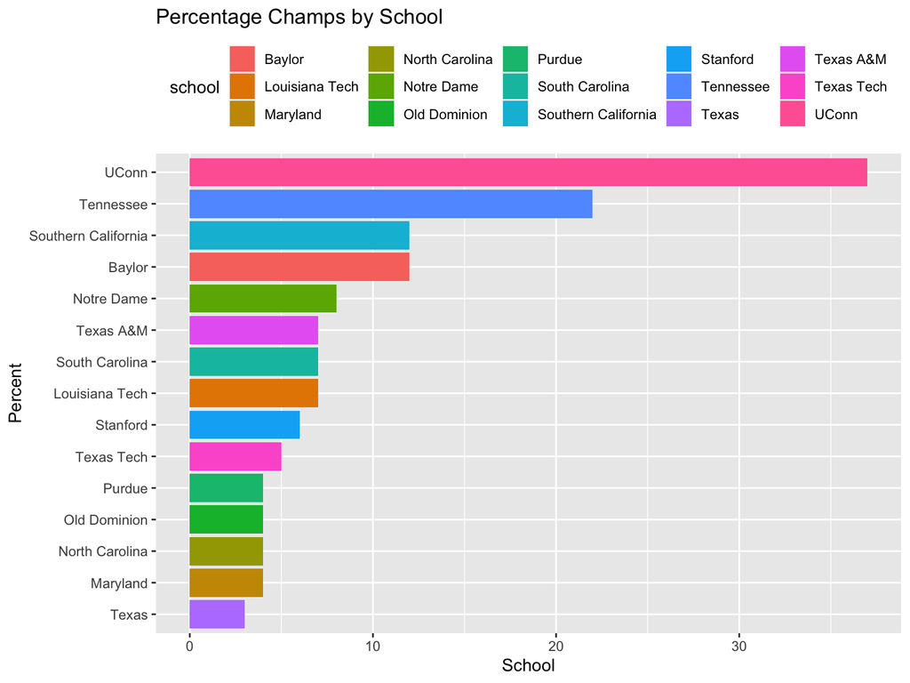

```r
pc <- ggplot(champs, aes(x = pct, y = reorder(school, pct), fill = school))
pc + geom_col(position = "dodge2") +
    labs(x = "School",y = "Percent", title = "Percentage Champs by School") +
    theme(legend.position = "top")
```

### What trends do you see? Who are the two teams that have won the most?

##I see that South Carolina, Texas A&M, and Louisianna Tech have all won the same percentage. UConn and Tennessee are the two teams that have won the most.

## Question 2

Let’s now look at how the top teams have been seeded as they enter into the tournament. Let’s begin by creating a dataset that includes just the “top teams”. How are we going to do this? Well, let’s take the teams that show up in your bar plot above. We are going to work with the dataset that only includes teams that have ever won the tournament. I’ll show you how to do it.

The dataset I created for the plot above is called `champs`. Let’s get the names of the champions:

```r
champ_names <- unique(champs$school)
```

Now, we filter our original name so that only these schools are included.

```r
winners <- wncaa %>%
  filter(school %in% champ_names)
```

Now, make a plot that shows boxplots for the distribution of `seeds` for each school. Make sure you use `coord_flip()` so that the school names are legible.

These days, it’s good practice to add all the data points in addition to the boxplot. You can use `geom_jitter()` to do this. Don’t forget to use `outlier.shape = NA` in the boxplot so you don’t plot the outliers twice.

We will also want to organize the plots so that they convey information more clearly. Use the `reorder()` trick to show the distributions in a an order that is easier to understand. You will need to calculate some school-specific statistics to use for the reordering. (You might find `group_by()` and `mutate()` valuable here, although there are several ways to do this.)

```r
winners <- winners |>
  group_by(school) |>
  mutate(mean_seed = mean(seed, na.rm = TRUE)) |>
  ungroup()
```

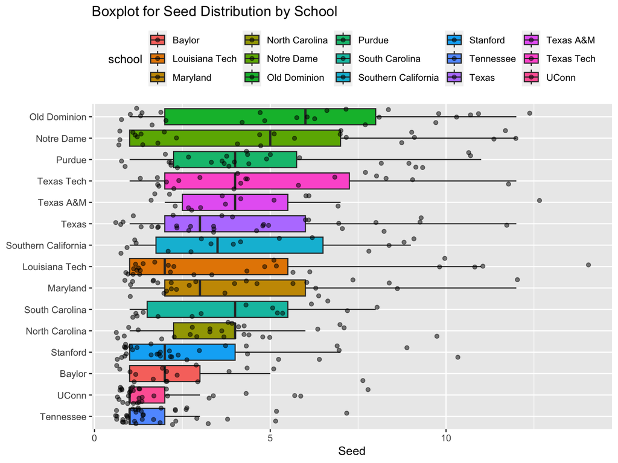

```r
wp <- ggplot(data = winners,
            mapping = aes(x = reorder(school, mean_seed, na.rm = TRUE), y = seed, fill = school))
wp + geom_boxplot(outlier.shape = NA) + geom_jitter(alpha = .5) +
  labs(x = NULL, y = "Seed", title = "Boxplot for Seed Distribution by School") +
  coord_flip() + theme(legend.position = "top")
```

### Describe the results? Any surprises?

##The school with the best mean seed is Tennessee followed by UConn. This is surprising because UConn (37%) has had a higher percentage of tournament wins than Tennessee (22%).

Try to make the same plot using `geom_violin()` instead of `geom_boxplot()`.

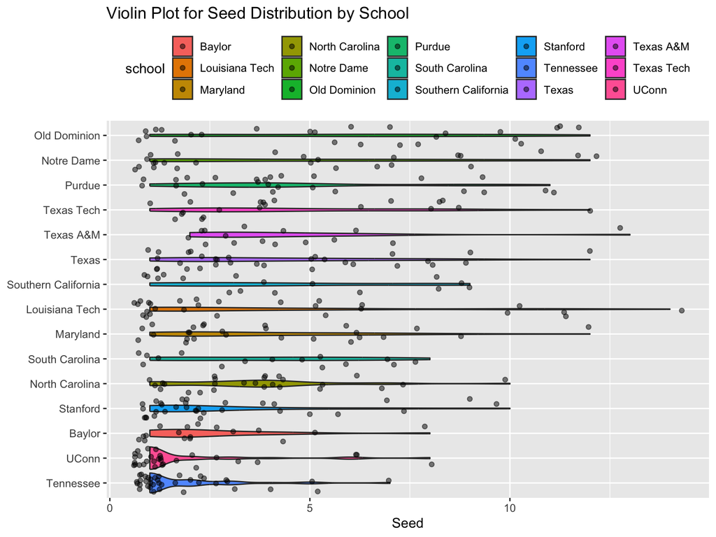

```r
wwp <- ggplot(data = winners,
            mapping = aes(x = reorder(school, mean_seed, na.rm = TRUE), y = seed, fill = school))
wwp + geom_violin(outlier.shape = NA) + geom_jitter(alpha = .5) +
  labs(x = NULL, y = "Seed", title = "Violin Plot for Seed Distribution by School") +
  coord_flip() + theme(legend.position = "top")
```

### Which visualization do you think is more informative? There’s no right answer here but provide some reasoning to justify your choice.

##I think the boxplot visualization is more informative because I don’t understand violin plots and there is no place where the violin graph indicates the mean seed for each school.

## Question 3

Try making the plot above but using `geom_point`.

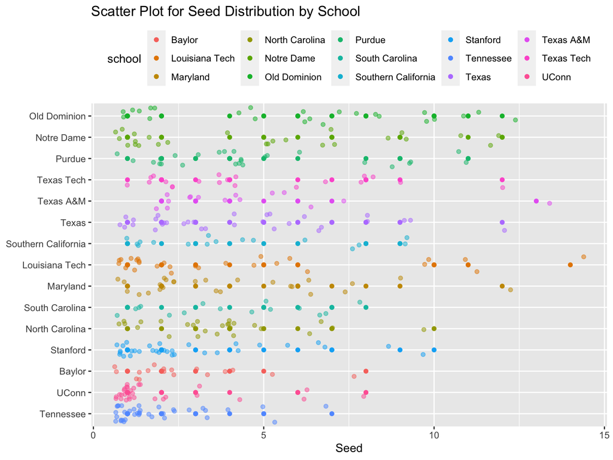

```r
wwpp <- ggplot(data = winners,
            mapping = aes(x = reorder(school, mean_seed, na.rm=TRUE),
                          y = seed, color = school))
wwpp + geom_point() + geom_jitter(alpha = .5) + labs(x=NULL, y = "Seed", title = "Scatter Plot for Seed Distribution by School") +
    coord_flip() + theme(legend.position = "top")
```

### Why does it not work very well?

##It doesn’t work very well because you can’t tell the average seed.

## Question 4

Okay, now let’s try the `summarize_if()` verb. Let’s make a new data frame by taking the `winners` dataset, grouping by school, and take the `mean()` and `sd()` of the columns **if** they are numeric. HINT: you can also use the newer `across()` syntax for this if you prefer. It looks like this:

```r
winners_mean_sd <- winners |>
  group_by(school) |>
  summarize(across(where(is.numeric),
                   list(mean = mean,
                        sd = sd)))
```

Let’s explore the average win percentage of these schools across the seasons. In your new dataset, this column should be called `reg_percent_mean`. Make a dot plot, where this column is in the y-axis and school is the x-axis. Again, use our tricks, `coord_flip` and `reorder` to make the plot legible.

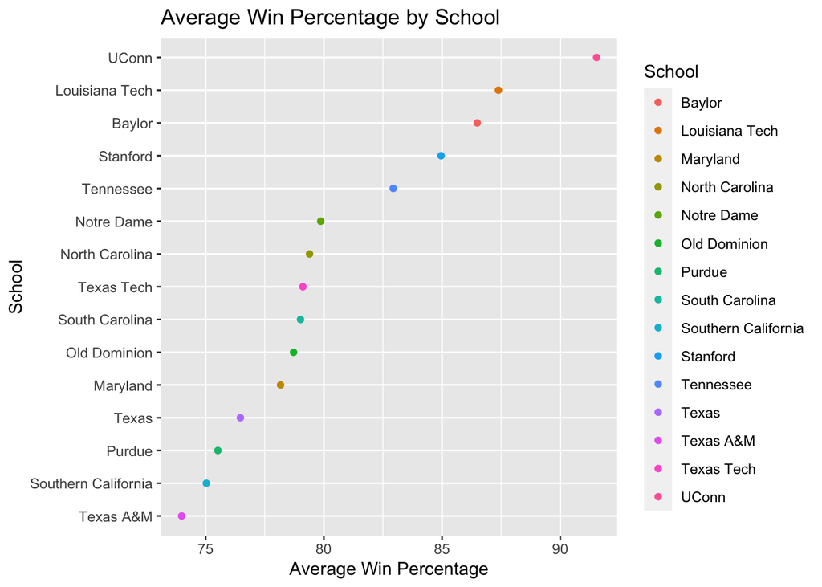

```r
ggplot(winners_mean_sd, aes(x = reorder(school, reg_percent_mean), y = reg_percent_mean, color = school)) +
  geom_point() + labs(x = "School", y = "Average Win Percentage", title = "Average Win Percentage by School", color = "School") +
  coord_flip()
```

### Describe the results. Which tournament winner had the lowest regular season win percentage?

##All schools that were tournament winners had fairly high regular season win percentages. The win percentages for these schools range from ~74% to ~92%. UConn had the highest percentage of tournament wins and the highest percentage of regular season wins. Texas A&M had the lowest regular season win percentage of all tournament winners.

Now, let’s try to take into account the standard deviation. Use the `geom_pointrange` to show the intervals of one standard deviation below and above the mean (just like Figure 5.15 in the online version of socviz.co).

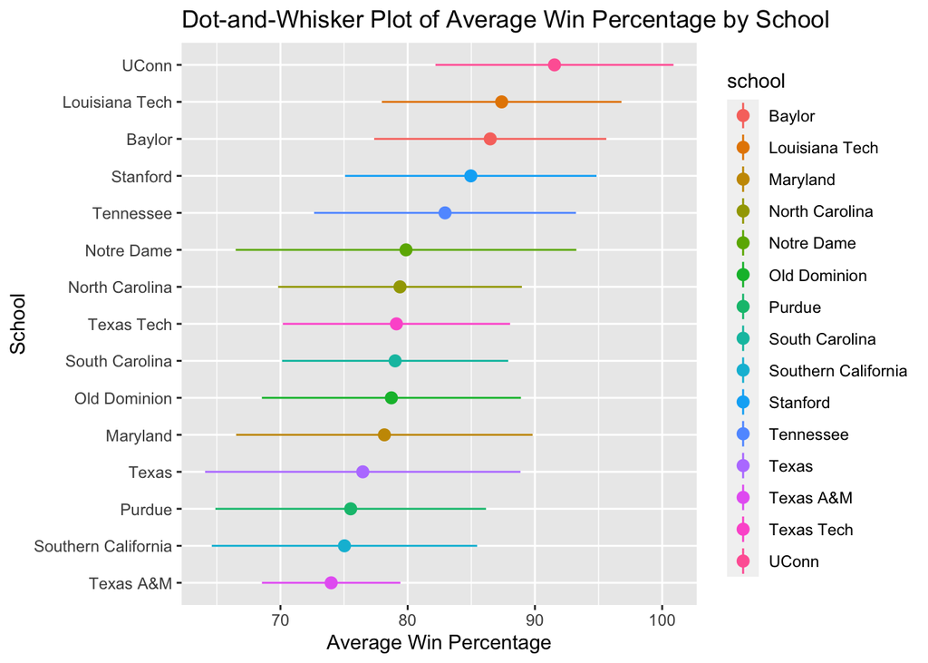

```r
pp <- ggplot(data = winners_mean_sd, mapping = aes(x = reorder(school,
              reg_percent_mean), y = reg_percent_mean, color = school))

pp + geom_pointrange(mapping = aes(ymin = reg_percent_mean - reg_percent_sd,
       ymax = reg_percent_mean + reg_percent_sd)) +
     labs(x= "School", y= "Average Win Percentage", title = "Dot-and-Whisker Plot of Average Win Percentage by School") + coord_flip()
```

### What is the school with the narrowest interval? What does this mean?

##The school with the narrowest interval is Texas A&M. Standard deviation is a measure of how dispersed the data is in relation to the mean. This means that Texas A&M’s win percentages across seasons are closer to their average win percentage than all other schools.

Can you make the same plot using `geom_linerange` ?

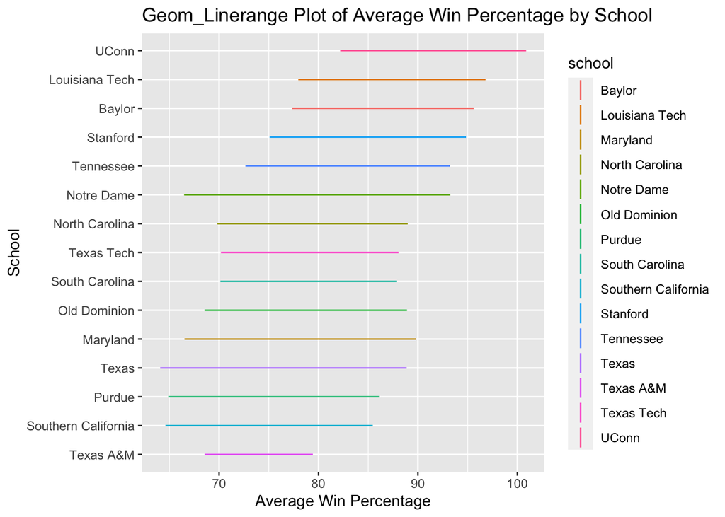

```r
ppp <- ggplot(data = winners_mean_sd, mapping = aes(x = reorder(school,
              reg_percent_mean), y = reg_percent_mean, color = school))

ppp + geom_linerange(mapping = aes(ymin = reg_percent_mean - reg_percent_sd,
       ymax = reg_percent_mean + reg_percent_sd)) +
     labs(x= "School", y= "Average Win Percentage", title = "Geom_Linerange Plot of Average Win Percentage by School") + coord_flip()
```

### Do you think this is a good or bad idea? Why? There is no right answer; just give your reasoning.

##I think this is a bad idea because you cannot there is no graph feature marking the average win percentage.